# 11.6 数据分析中的常用方法及运用场景（入门）

> 本节是一个**工具箱导览**：从“该用什么方法”到“如何快速落地”。配套 Python 小例子都能直接运行，适合人文社科初学者。

## 学习目标

- 认识常见数据分析方法与**典型运用场景**。
- 熟悉 Python 常用库在数据分析中的**定位与分工**。
- 会用**最小代码**完成：描述统计、频数/交叉表、文本词频、时间序列折线图。
- 能根据研究问题**选择合适方法**，并知道常见**坑点**与规避策略。

## 11.6.1 常用方法及运用场景（速查表）

| 方法名称 | 描述 | 运用场景 |
| --- | --- | --- |
| 描述性统计 | 总结均值、中位数、标准差等 | 学生成绩分布、问卷汇总 |
| 数据清洗 | 处理缺失、重复、异常 | 文献/问卷/社交数据清洗 |
| 数据可视化 | 图表展示分布与关系 | 趋势分析、词频可视化 |
| 假设检验 | 检验样本是否支持总体假设 | 成绩差异显著性 |
| 相关性分析 | 计算变量相关程度 | 投入与结果关系 |
| 回归分析 | 构建预测模型 | 房价/成绩预测 |
| 文本分析 | 分词、词频、情感 | 诗歌情感、话题挖掘 |
| 聚类分析 | 无监督分组 | 消费者群体划分 |
| 时间序列分析 | 研究随时间的变化 | 历史趋势、价格变化 |
| 主成分分析（PCA） | 高维降维 | 特征压缩与解释 |
| 频数分析 | 分类频率与占比 | 性别/职业分布 |
| 交叉表分析 | 分类变量关系 | 性别×职业对应关系 |

## 11.6.2 常用 Python 库（做什么用？）

- **Pandas**：表格数据读取、整理、聚合分析（CSV/Excel 等）。
- **NumPy**：数组运算与数学函数（Pandas 的底层伙伴）。
- **Matplotlib**：绘图（**本节只用它**，保证环境通用）。
- **SciPy / Statsmodels**：统计检验与回归（可选）。
- **Scikit-learn**：机器学习建模（聚类、PCA、回归等，入门了解即可）。
- **NLTK / TextBlob**：文本处理（本节用 Python 内置方法演示词频）。

## 语法要点（本节会用到）

- `pd.Series(...).mean()/median()/std()`：描述统计。
- `value_counts(normalize=...)`：频数与占比；`pd.crosstab()`：交叉表。
- `Counter(text)`：粗粒度词频（中文逐字演示）。
- `pd.date_range(...); Series.plot()`：时间序列折线图（用 matplotlib）。

## 示例 1：学生成绩的描述统计与直方图

- 目标：一眼看出成绩的**中心**与**离散**。
- 指标：均值、中位数、标准差。
- 图：直方图（附核密度在进阶中可用 seaborn，但本节仅用 matplotlib）。

```
均值: 85.5
中位数: 86.5
标准差: 6.93
```

[figure not shown]

```python
import pandas as pd
import matplotlib.pyplot as plt

scores = pd.Series([80, 85, 90, 78, 88, 92, 76, 95])
print("均值:", round(scores.mean(), 2))
print("中位数:", round(scores.median(), 2))
print("标准差:", round(scores.std(), 2))

plt.figure()
plt.hist(scores, bins=5)  # 直方图
plt.title("学生成绩分布")
plt.xlabel("成绩")
plt.ylabel("人数")
plt.show()
```

## 示例 2：调查问卷的频数与交叉表分析

- 频数与占比常用于问卷**单题统计**；交叉表用于**两个分类变量**的关系展示。

```python
import pandas as pd

df = pd.DataFrame({
    '性别': ['男','女','女','男','女','男'],
    '职业': ['学生','教师','学生','教师','学生','学生']
})

# 频数与占比
print("职业频数：")
print(df['职业'].value_counts())
print("\n职业占比：")
print(df['职业'].value_counts(normalize=True).round(3))

# 交叉表
print("\n性别×职业 交叉表：")
print(pd.crosstab(df['性别'], df['职业']))
```

```
职业频数：
职业
学生    4
教师    2
Name: count, dtype: int64

职业占比：
职业
学生    0.667
教师    0.333
Name: proportion, dtype: float64

性别×职业 交叉表：
职业  学生  教师
性别
女    2   1
男    2   1
```

## 示例 3：文本词频（逐字统计）

> 入门演示：按**字**统计《春晓》的字频。进阶可做分词、去停用词、情感分析。

```python
from collections import Counter

text = "春眠不觉晓，处处闻啼鸟。夜来风雨声，花落知多少。"
words = list(text)  # 入门：逐字统计；进阶可换成分词结果
freq = Counter(words)

# 打印前若干高频字
for k, v in list(freq.items())[:10]:
    print(f"{k}: {v}")
```

```
春: 1
眠: 1
不: 1
觉: 1
晓: 1
，: 2
处: 2
闻: 1
啼: 1
鸟: 1
```

## 示例 4：历史数据的时间序列折线图

- 目标：观察**年度趋势**与波动。
- 做法：`date_range` 生成日期索引 + 折线图。

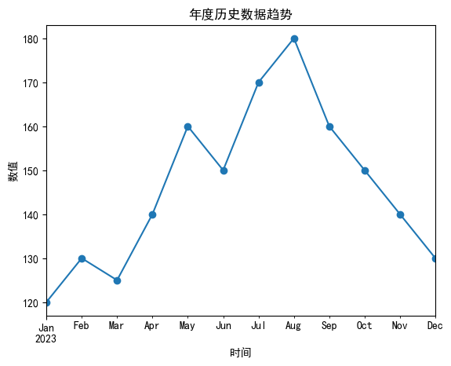

```python
import pandas as pd
import matplotlib.pyplot as plt

# 设置支持中文的字体，例如黑体
plt.rcParams['font.sans-serif'] = ['SimHei']  # 或者 'Microsoft YaHei', 'FangSong', 'KaiTi' 等
plt.rcParams['axes.unicode_minus'] = False  # 解决负号显示问题

dates = pd.date_range(start='2023-01', periods=12, freq='M')
values = [120, 130, 125, 140, 160, 150, 170, 180, 160, 150, 140, 130]
ts = pd.Series(values, index=dates)

plt.figure()
ts.plot(marker='o')
plt.title("年度历史数据趋势")
plt.ylabel("数值")
plt.xlabel("时间")
plt.show()
```

### （可选进阶）PCA 降维与 KMeans 聚类（仅当 scikit-learn 可用）

- 场景：高维指标想要**压缩与解释**（PCA），或**自动分组**（聚类）。

```python
import numpy as np

# 构造小数据：两个相关变量 + 少量噪声
np.random.seed(0)
X = np.column_stack([
    np.linspace(0, 10, 30),
    np.linspace(0, 10, 30) + np.random.normal(0, 1, 30)
])

try:
    from sklearn.decomposition import PCA
    from sklearn.cluster import KMeans

    pca = PCA(n_components=1).fit(X)
    X1 = pca.transform(X)  # 压成 1 维
    kmeans = KMeans(n_clusters=2, n_init=10, random_state=0).fit(X)
    labels = kmeans.labels_

    print("PCA：第一主成分方差解释率 ≈", round(pca.explained_variance_ratio_[0], 3))
    print("KMeans：簇标签（前10项）", labels[:10])
except Exception as e:
    print("（提示）未检测到 scikit-learn，跳过 PCA/KMeans 演示。")
```

```
PCA：第一主成分方差解释率 ≈ 0.967
KMeans：簇标签（前10项） [1 1 1 1 1 1 1 1 1 1]
```